# MainAnalyses

Yuyan Xu

2023-08-27

# Descriptive statistics

### Horizon task (**main text table 2**)

Summary Statistics

| Variable | N | Mean | Std. Dev. | Min | Pctl. 25 | Pctl. 75 | Max |
| --- | --- | --- | --- | --- | --- | --- | --- |
| directed_exploration | 78 | 0.52 | 0.085 | 0.36 | 0.46 | 0.57 | 0.71 |
| strategic_exploration | 78 | 0.034 | 0.1 | -0.15 | -0.04 | 0.075 | 0.33 |
| rt_5thchoice | 78 | 1.4 | 0.58 | 0.48 | 0.99 | 1.8 | 3 |
| reward_maximization | 78 | 0.82 | 0.12 | 0.3 | 0.78 | 0.9 | 0.97 |
| mean_reward | 78 | 55 | 1.9 | 49 | 55 | 56 | 58 |

Summary Statistics

| Variable | N | Mean | Std. Dev. | Min | Pctl. 25 | Pctl. 75 | Max |
| --- | --- | --- | --- | --- | --- | --- | --- |
| directed_exploration | 84 | 0.48 | 0.097 | 0.21 | 0.44 | 0.54 | 0.7 |
| strategic_exploration | 84 | 0.033 | 0.14 | -0.3 | -0.05 | 0.12 | 0.38 |
| rt_5thchoice | 74 | 1.5 | 1 | 0.26 | 0.87 | 1.9 | 6.8 |
| reward_maximization | 84 | 0.79 | 0.12 | 0.38 | 0.75 | 0.85 | 0.95 |
| mean_reward | 84 | 54 | 1.8 | 48 | 53 | 56 | 57 |

```
##      Dependent Variable           t  df          p           d    CI_lower
## 1  directed_exploration  2.29083831 160 0.02327794  0.36021766  0.04896088
## 2 strategic_exploration  0.08066073 160 0.93581258  0.01268331 -0.29552966
## 3          rt_5thchoice -0.38473939 150 0.70097545 -0.06243459 -0.38046716
## 4   reward_maximization  1.89965820 160 0.05927719  0.29870743 -0.01167426
## 5           mean_reward  2.35142733 160 0.01991984  0.36974484  0.05833973
##    CI_upper
## 1 0.6703668
## 2 0.3208567
## 3 0.2558060
## 4 0.6081663
## 5 0.6800140
```

### Questionnaires (**main text table 3**)

Summary Statistics

| Variable | N | Mean | Std. Dev. | Min | Pctl. 25 | Pctl. 75 | Max |
| --- | --- | --- | --- | --- | --- | --- | --- |
| unpredictability | 78 | 5.6 | 5.1 | 0 | 1 | 8.8 | 22 |
| family_income | 78 | 4.3 | 1.4 | 1 | 3 | 5 | 6 |
| digit_span | 78 | 11 | 3.2 | 4 | 8 | 14 | 19 |

Summary Statistics

| Variable | N | Mean | Std. Dev. | Min | Pctl. 25 | Pctl. 75 | Max |
| --- | --- | --- | --- | --- | --- | --- | --- |
| unpredictability | 84 | 6.1 | 5.7 | 0 | 1.1 | 9 | 27 |
| family_income | 84 | 4.6 | 1.3 | 1 | 3 | 6 | 6 |
| digit_span | 84 | 16 | 5.5 | 0 | 13 | 18 | 29 |

```
##   Dependent Variable          t  df            p           d   CI_lower
## 1   unpredictability -0.6101043 160 5.426583e-01 -0.09593446 -0.4041538
## 2      family_income -1.1219230 160 2.635761e-01 -0.17641423 -0.4849344
## 3         digit_span -6.7230755 160 2.979543e-10 -1.05715471 -1.3849033
##     CI_upper
## 1  0.2125841
## 2  0.1326548
## 3 -0.7264931
```

### Orchard task (**main text results**)

```
##       Dependent Variable         t df            p         d  CI_lower CI_upper
## 1        threshold_short 43.816353 75 3.459715e-55 5.0260804 4.1906693 5.844483
## 2        threshold_short 43.816353 75 3.459715e-55 5.0260804 4.1906693 5.844483
## 3  dev_from_optimal_long  5.887780 75 1.032015e-07 0.6753747 0.4241554 0.922903
## 4 dev_from_optimal_short  6.090573 75 4.442685e-08 0.6986366 0.4457469 0.947755
```

# Baseline evidence of exploration under task manipulation

### Horizon task (**main text table 1**)

```
##                                                                   rownames
## 1                           average directed exploration (1-sample t-test)
## 2                       directed exploration in H1 games (1-sample t-test)
## 3                       directed exploration in H6 games (1-sample t-test)
## 4 strategic directed exploration (2-sample t-test between H1 and H6 games)
##           t  df             p          d   CI_lower    CI_upper
## 1 64.449432 155 7.990415e-114  5.1600843  4.5562997  5.74722330
## 2 52.816142  77  3.052301e-62  5.9802504  4.9906016  6.93106647
## 3 41.980546  77  8.063020e-55  4.7533608  3.9701219  5.52077982
## 4 -2.159507 154  1.617929e-02 -0.3457979 -0.6617116 -0.02903628
```

```
##                                                                   rownames
## 1                           average directed exploration (1-sample t-test)
## 2                       directed exploration in H1 games (1-sample t-test)
## 3                       directed exploration in H6 games (1-sample t-test)
## 4 strategic directed exploration (2-sample t-test between H1 and H6 games)
##           t  df             p          d   CI_lower   CI_upper
## 1 52.622967 167 6.910432e-106  4.0599501  3.5929545 4.51479004
## 2 38.673081  83  7.343520e-55  4.2195791  3.5423681 4.88344874
## 3 36.516436  83  6.618742e-53  3.9842698  3.3408196 4.61498679
## 4 -1.789487 166  3.767978e-02 -0.2761238 -0.5795939 0.02816982
```

### Orchard task (**main text results**)

```
## Linear mixed model fit by REML. t-tests use Satterthwaite's method [
## lmerModLmerTest]
## Formula: exit_threshold ~ environment_type + (environment_type | id)
##    Data: tr_long
## Control: control
##
## REML criterion at convergence: 8095.8
##
## Scaled residuals:
##     Min      1Q  Median      3Q     Max
## -5.9805 -0.4729  0.0424  0.5620  3.6943
##
## Random effects:
##  Groups   Name                  Variance Std.Dev. Corr
##  id       (Intercept)           3.798    1.949
##           environment_typeshort 1.217    1.103    -0.68
##  Residual                       1.684    1.298
## Number of obs: 2288, groups:  id, 76
##
## Fixed effects:
##                       Estimate Std. Error      df t value Pr(>|t|)
## (Intercept)             6.6889     0.2282 74.4895  29.309  < 2e-16 ***
## environment_typeshort   0.9101     0.1395 70.3451   6.526 8.88e-09 ***
## ---
## Signif. codes:  0 '***' 0.001 '**' 0.01 '*' 0.05 '.' 0.1 ' ' 1
##
## Correlation of Fixed Effects:
##             (Intr)
## envrnmnt_ty -0.671
```

# Is childhood unpredictability associated with reduced exploration?

### Horizon task

##### Directed exploration (**main text results**)

###### Study 1

In the model output below, check **unpredictability** for whether there is an effect of childhood unpredictability on directed exploration.

```
##
## Call:
## lm(formula = directed_exploration ~ unpredictability + digit_span +
##     family_income + child_anxiety, data = hr_wide_study1)
##
## Residuals:
##       Min        1Q    Median        3Q       Max
## -0.157767 -0.063605 -0.005827  0.069173  0.177462
##
## Coefficients:
##                    Estimate Std. Error t value Pr(>|t|)
## (Intercept)       0.5174732  0.0094827  54.571   <2e-16 ***
## unpredictability -0.0239491  0.0115227  -2.078   0.0412 *
## digit_span       -0.0137433  0.0101289  -1.357   0.1790
## family_income    -0.0129218  0.0117044  -1.104   0.2732
## child_anxiety     0.0007831  0.0102664   0.076   0.9394
## ---
## Signif. codes:  0 '***' 0.001 '**' 0.01 '*' 0.05 '.' 0.1 ' ' 1
##
## Residual standard error: 0.08368 on 73 degrees of freedom
## Multiple R-squared:  0.07979,    Adjusted R-squared:  0.02937
## F-statistic: 1.582 on 4 and 73 DF,  p-value: 0.1881
```

|  | directed exploration |  |  |
| --- | --- | --- | --- |
| Predictors | Estimates | CI | p |
| (Intercept) | 0.52 | 0.50 – 0.54 | **<0.001** |
| unpredictability | -0.02 | -0.05 – -0.00 | **0.041** |
| digit span | -0.01 | -0.03 – 0.01 | 0.179 |
| family income | -0.01 | -0.04 – 0.01 | 0.273 |
| child anxiety | 0.00 | -0.02 – 0.02 | 0.939 |
| Observations | 78 |  |  |
| R<sup>2</sup> / R<sup>2</sup> adjusted | 0.080 / 0.029 |  |  |

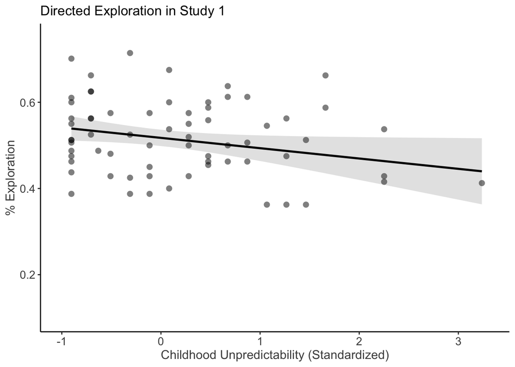

###### Study 2

```
##
## Call:
## lm(formula = directed_exploration ~ unpredictability + digit_span +
##     family_income + perceived_stress, data = hr_wide_study2)
##
## Residuals:
##      Min       1Q   Median       3Q      Max
## -0.21709 -0.06015 -0.00222  0.06043  0.19720
##
## Coefficients:
##                   Estimate Std. Error t value Pr(>|t|)
## (Intercept)       0.433469   0.030490  14.217  < 2e-16 ***
## unpredictability -0.047453   0.010983  -4.321 4.83e-05 ***
## digit_span        0.001304   0.010385   0.126   0.9004
## family_income    -0.024233   0.010335  -2.345   0.0218 *
## perceived_stress  0.003108   0.001816   1.712   0.0912 .
## ---
## Signif. codes:  0 '***' 0.001 '**' 0.01 '*' 0.05 '.' 0.1 ' ' 1
##
## Residual standard error: 0.08702 on 73 degrees of freedom
##   (6 observations deleted due to missingness)
## Multiple R-squared:  0.2398, Adjusted R-squared:  0.1982
## F-statistic: 5.757 on 4 and 73 DF,  p-value: 0.0004393
```

|  | directed exploration |  |  |
| --- | --- | --- | --- |
| Predictors | Estimates | CI | p |
| (Intercept) | 0.43 | 0.37 – 0.49 | **<0.001** |
| unpredictability | -0.05 | -0.07 – -0.03 | **<0.001** |
| digit span | 0.00 | -0.02 – 0.02 | 0.900 |
| family income | -0.02 | -0.04 – -0.00 | **0.022** |
| perceived stress | 0.00 | -0.00 – 0.01 | 0.091 |
| Observations | 78 |  |  |
| R<sup>2</sup> / R<sup>2</sup> adjusted | 0.240 / 0.198 |  |  |

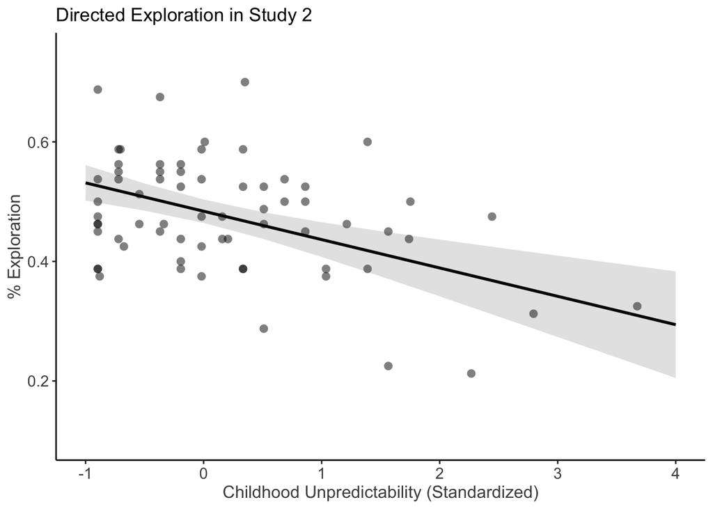

##### Strategic directed exploration (**main text results**)

###### Study 1

In the model output below, check **horizon:unpredictability** for whether there is an effect of childhood unpredictability on strategic exploration.

```
## Generalized linear mixed model fit by maximum likelihood (Laplace
##   Approximation) [glmerMod]
##  Family: binomial  ( logit )
## Formula: chose_high_info_value ~ horizon * conflict * unpredictability +
##     digit_span + family_income + child_anxiety + (1 + horizon +
##     conflict | id)
##    Data: hr_long_study1
## Control: control
##
##      AIC      BIC   logLik deviance df.resid
##   6561.8   6676.2  -3263.9   6527.8     6172
##
## Scaled residuals:
##     Min      1Q  Median      3Q     Max
## -2.9183 -0.5442  0.3744  0.5390  3.9123
##
## Random effects:
##  Groups Name        Variance Std.Dev. Corr
##  id     (Intercept) 0.38738  0.6224
##         horizon1    0.04302  0.2074    0.15
##         conflict1   0.97688  0.9884   -0.93  0.24
## Number of obs: 6189, groups:  id, 78
##
## Fixed effects:
##                                      Estimate Std. Error z value Pr(>|z|)
## (Intercept)                         -1.597288   0.101517 -15.734  < 2e-16 ***
## horizon1                             0.698152   0.096977   7.199 6.06e-13 ***
## conflict1                            2.935559   0.147221  19.940  < 2e-16 ***
## unpredictability                     0.165129   0.104821   1.575  0.11517
## digit_span                          -0.092765   0.053465  -1.735  0.08273 .
## family_income                       -0.052553   0.060950  -0.862  0.38856
## child_anxiety                        0.009324   0.054737   0.170  0.86474
## horizon1:conflict1                  -0.858620   0.127768  -6.720 1.82e-11 ***
## horizon1:unpredictability           -0.201122   0.092465  -2.175  0.02962 *
## conflict1:unpredictability          -0.437962   0.143355  -3.055  0.00225 **
## horizon1:conflict1:unpredictability  0.215496   0.121596   1.772  0.07636 .
## ---
## Signif. codes:  0 '***' 0.001 '**' 0.01 '*' 0.05 '.' 0.1 ' ' 1
##
## Correlation of Fixed Effects:
```

[output cut: 9 more lines]

```
## cnflct1:npr  0.037 -0.035 -0.046 -0.799 -0.011 -0.007  0.008  0.050  0.393
## hrzn1:cnf1: -0.040  0.049  0.050  0.365  0.020  0.010 -0.004 -0.076 -0.712
##             cnfl1:
## horizon1
## conflict1
## unprdctblty
## digit_span
## family_incm
## child_anxty
## hrzn1:cnfl1
## hrzn1:nprdc
## cnflct1:npr
## hrzn1:cnf1: -0.453
## optimizer (bobyqa) convergence code: 0 (OK)
## boundary (singular) fit: see help('isSingular')
```

|  | chose high info value |  |  |
| --- | --- | --- | --- |
| Predictors | Odds Ratios | CI | p |
| (Intercept) | 0.20 | 0.17 – 0.25 | **<0.001** |
| horizon [1] | 2.01 | 1.66 – 2.43 | **<0.001** |
| conflict [1] | 18.83 | 14.11 – 25.13 | **<0.001** |
| unpredictability | 1.18 | 0.96 – 1.45 | 0.115 |
| digit span | 0.91 | 0.82 – 1.01 | 0.083 |
| family income | 0.95 | 0.84 – 1.07 | 0.389 |
| child anxiety | 1.01 | 0.91 – 1.12 | 0.865 |
| horizon [1] * conflict [1] | 0.42 | 0.33 – 0.54 | **<0.001** |
| horizon [1] * unpredictability | 0.82 | 0.68 – 0.98 | **0.030** |
| conflict [1] * unpredictability | 0.65 | 0.49 – 0.85 | **0.002** |
| (horizon [1] * conflict [1]) * unpredictability | 1.24 | 0.98 – 1.57 | 0.076 |
| Random Effects |  |  |  |
| σ<sup>2</sup> | 3.29 |  |  |
| τ<sub>00</sub> <sub>id</sub> | 0.39 |  |  |
| τ<sub>11</sub> <sub>id.horizon1</sub> | 0.04 |  |  |
| τ<sub>11</sub> <sub>id.conflict1</sub> | 0.98 |  |  |
| ρ<sub>01</sub> | 0.15 |  |  |
|  | -0.93 |  |  |
| ICC | 0.10 |  |  |
| N <sub>id</sub> | 78 |  |  |
| Observations | 6189 |  |  |
| Marginal R<sup>2</sup> / Conditional R<sup>2</sup> | 0.314 / 0.384 |  |  |

```
## $emtrends
##  horizon unpredictability.trend     SE  df asymp.LCL asymp.UCL
##  0                      -0.0539 0.0642 Inf    -0.180   0.07197
##  1                      -0.1472 0.0742 Inf    -0.293  -0.00185
##
## Results are averaged over the levels of: conflict
## Confidence level used: 0.95
##
## $contrasts
##  contrast            estimate     SE  df z.ratio p.value
##  horizon0 - horizon1   0.0934 0.0652 Inf   1.433  0.1518
##
## Results are averaged over the levels of: conflict
```

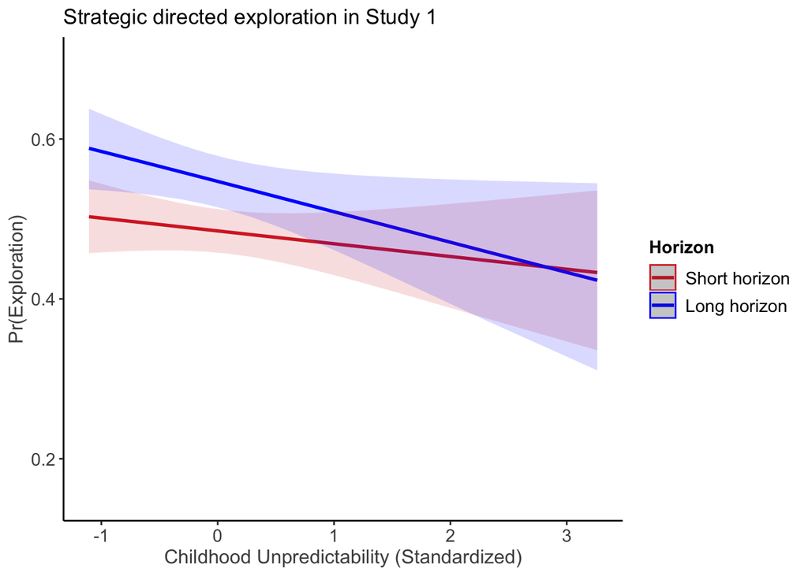

###### Study 2

```
## Generalized linear mixed model fit by maximum likelihood (Laplace
##   Approximation) [glmerMod]
##  Family: binomial  ( logit )
## Formula: chose_high_info_value ~ horizon * conflict * unpredictability +
##     digit_span + family_income + perceived_stress + (1 + horizon +
##     conflict | id)
##    Data: hr_long_study2
## Control: control
##
##      AIC      BIC   logLik deviance df.resid
##   6968.0   7082.6  -3467.0   6934.0     6223
##
## Scaled residuals:
##     Min      1Q  Median      3Q     Max
## -2.9279 -0.6027 -0.3052  0.6336  3.5595
##
## Random effects:
##  Groups Name        Variance Std.Dev. Corr
##  id     (Intercept) 0.5842   0.7643
##         horizon1    0.1522   0.3901   -0.19
##         conflict1   1.0541   1.0267   -0.90  0.05
## Number of obs: 6240, groups:  id, 78
##
## Fixed effects:
##                                      Estimate Std. Error z value Pr(>|z|)
## (Intercept)                         -1.759747   0.182360  -9.650  < 2e-16 ***
## horizon1                             0.428801   0.101841   4.211 2.55e-05 ***
## conflict1                            2.452605   0.148241  16.545  < 2e-16 ***
## unpredictability                    -0.051296   0.109501  -0.468 0.639461
## digit_span                           0.028334   0.049999   0.567 0.570929
## family_income                       -0.140188   0.050694  -2.765 0.005685 **
## perceived_stress                     0.019208   0.009128   2.104 0.035343 *
## horizon1:conflict1                  -0.480251   0.124268  -3.865 0.000111 ***
## horizon1:unpredictability           -0.188787   0.097505  -1.936 0.052844 .
## conflict1:unpredictability          -0.286307   0.140975  -2.031 0.042264 *
## horizon1:conflict1:unpredictability  0.193242   0.116466   1.659 0.097072 .
## ---
## Signif. codes:  0 '***' 0.001 '**' 0.01 '*' 0.05 '.' 0.1 ' ' 1
##
## Correlation of Fixed Effects:
##             (Intr) horzn1 cnflc1 unprdc dgt_sp fmly_n prcvd_ hrz1:1 hrzn1:
## horizon1    -0.278
## conflict1   -0.515  0.328
## unprdctblty  0.182  0.015  0.020
## digit_span  -0.026  0.005  0.008  0.010
## family_incm  0.245  0.005 -0.015  0.069 -0.154
## prcvd_strss -0.793 -0.018  0.001 -0.248  0.006 -0.286
## hrzn1:cnfl1  0.186 -0.665 -0.446 -0.016 -0.007 -0.009  0.026
## hrzn1:nprdc  0.001 -0.008 -0.008 -0.449  0.004 -0.008  0.007  0.007
## cnflct1:npr  0.006 -0.007 -0.039 -0.826  0.004 -0.004  0.007  0.028  0.315
## hrzn1:cnf1:  0.005  0.004  0.028  0.324 -0.007  0.012 -0.011 -0.054 -0.676
##             cnfl1:
## horizon1
## conflict1
## unprdctblty
## digit_span
## family_incm
## prcvd_strss
## hrzn1:cnfl1
## hrzn1:nprdc
## cnflct1:npr
## hrzn1:cnf1: -0.427
```

|  | chose high info value |  |  |
| --- | --- | --- | --- |
| Predictors | Odds Ratios | CI | p |
| (Intercept) | 0.17 | 0.12 – 0.25 | **<0.001** |
| horizon [1] | 1.54 | 1.26 – 1.87 | **<0.001** |
| conflict [1] | 11.62 | 8.69 – 15.54 | **<0.001** |
| unpredictability | 0.95 | 0.77 – 1.18 | 0.639 |
| digit span | 1.03 | 0.93 – 1.13 | 0.571 |
| family income | 0.87 | 0.79 – 0.96 | **0.006** |
| perceived stress | 1.02 | 1.00 – 1.04 | **0.035** |
| horizon [1] * conflict [1] | 0.62 | 0.48 – 0.79 | **<0.001** |
| horizon [1] * unpredictability | 0.83 | 0.68 – 1.00 | 0.053 |
| conflict [1] * unpredictability | 0.75 | 0.57 – 0.99 | **0.042** |
| (horizon [1] * conflict [1]) * unpredictability | 1.21 | 0.97 – 1.52 | 0.097 |
| Random Effects |  |  |  |
| σ<sup>2</sup> | 3.29 |  |  |
| τ<sub>00</sub> <sub>id</sub> | 0.58 |  |  |
| τ<sub>11</sub> <sub>id.horizon1</sub> | 0.15 |  |  |
| τ<sub>11</sub> <sub>id.conflict1</sub> | 1.05 |  |  |
| ρ<sub>01</sub> | -0.19 |  |  |
|  | -0.90 |  |  |
| ICC | 0.12 |  |  |
| N <sub>id</sub> | 78 |  |  |
| Observations | 6240 |  |  |
| Marginal R<sup>2</sup> / Conditional R<sup>2</sup> | 0.261 / 0.347 |  |  |

```
## $emtrends
##  horizon unpredictability.trend     SE  df asymp.LCL asymp.UCL
##  0                       -0.194 0.0649 Inf    -0.322   -0.0672
##  1                       -0.287 0.0694 Inf    -0.423   -0.1506
##
## Results are averaged over the levels of: conflict
## Confidence level used: 0.95
##
## $contrasts
##  contrast            estimate     SE  df z.ratio p.value
##  horizon0 - horizon1   0.0922 0.0723 Inf   1.275  0.2022
##
## Results are averaged over the levels of: conflict
```

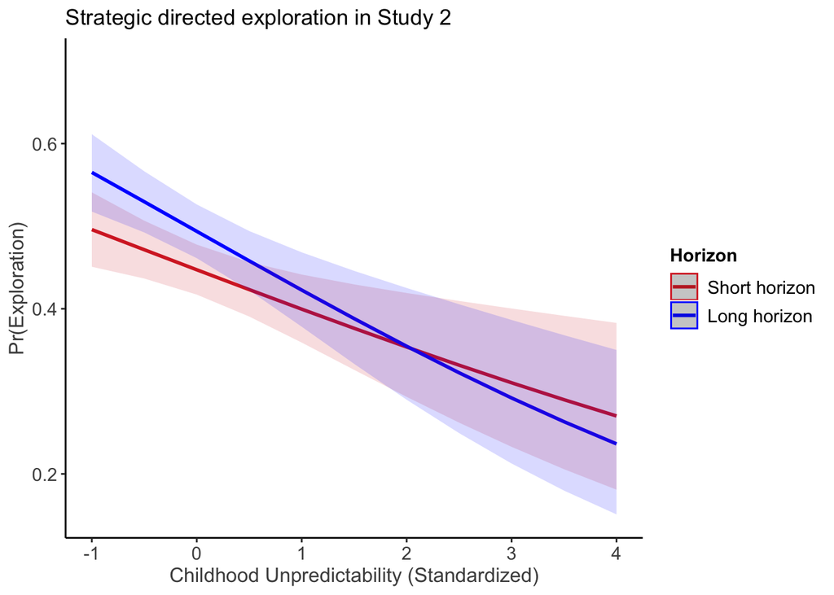

### Bonus: effect of parent-report of unpredictability (**main text results**)

Note: parent-report of unpredictability is only assessed in Primary Study (study 1) In the model output below, check **life_events** for whether there is an effect of parent-report of unpredictability on directed exploration.

```
##
## Call:
## lm(formula = directed_exploration ~ life_events + digit_span +
##     family_income + child_anxiety, data = hr_wide_study1)
##
## Residuals:
##       Min        1Q    Median        3Q       Max
## -0.170992 -0.054005 -0.008354  0.062134  0.202961
##
## Coefficients:
##                Estimate Std. Error t value Pr(>|t|)
## (Intercept)    0.504651   0.016924  29.819   <2e-16 ***
## life_events    0.002837   0.003524   0.805    0.424
## digit_span    -0.013562   0.010507  -1.291    0.201
## family_income  0.003738   0.010781   0.347    0.730
## child_anxiety -0.003875   0.010310  -0.376    0.708
## ---
## Signif. codes:  0 '***' 0.001 '**' 0.01 '*' 0.05 '.' 0.1 ' ' 1
##
## Residual standard error: 0.08523 on 72 degrees of freedom
##   (1 observation deleted due to missingness)
## Multiple R-squared:  0.03804,    Adjusted R-squared:  -0.0154
## F-statistic: 0.7118 on 4 and 72 DF,  p-value: 0.5865
```

|  | directed exploration |  |  |
| --- | --- | --- | --- |
| Predictors | Estimates | CI | p |
| (Intercept) | 0.50 | 0.47 – 0.54 | **<0.001** |
| life events | 0.00 | -0.00 – 0.01 | 0.424 |
| digit span | -0.01 | -0.03 – 0.01 | 0.201 |
| family income | 0.00 | -0.02 – 0.03 | 0.730 |
| child anxiety | -0.00 | -0.02 – 0.02 | 0.708 |
| Observations | 77 |  |  |
| R<sup>2</sup> / R<sup>2</sup> adjusted | 0.038 / -0.015 |  |  |

```
## Generalized linear mixed model fit by maximum likelihood (Laplace
##   Approximation) [glmerMod]
##  Family: binomial  ( logit )
## Formula:
## chose_high_info_value ~ horizon * conflict * life_events + digit_span +
##     family_income + child_anxiety + (1 + horizon + conflict |      id)
##    Data: hr_long_study1
## Control: control
##
##      AIC      BIC   logLik deviance df.resid
##   6503.9   6618.1  -3234.9   6469.9     6092
##
## Scaled residuals:
##     Min      1Q  Median      3Q     Max
## -2.9707 -0.5568  0.3850  0.5446  3.7790
##
## Random effects:
##  Groups Name        Variance Std.Dev. Corr
##  id     (Intercept) 0.41632  0.6452
##         horizon1    0.05069  0.2251    0.06
##         conflict1   1.01074  1.0054   -0.93  0.32
## Number of obs: 6109, groups:  id, 77
##
## Fixed effects:
##                                Estimate Std. Error z value Pr(>|z|)
## (Intercept)                    -1.83820    0.17017 -10.802  < 2e-16 ***
## horizon1                        0.75025    0.15697   4.780 1.76e-06 ***
## conflict1                       3.28456    0.24409  13.456  < 2e-16 ***
## life_events                     0.06168    0.03323   1.856   0.0635 .
## digit_span                     -0.09836    0.05482  -1.794   0.0728 .
## family_income                   0.02059    0.05605   0.367   0.7134
## child_anxiety                  -0.01074    0.05434  -0.198   0.8433
## horizon1:conflict1             -0.88173    0.20699  -4.260 2.05e-05 ***
## horizon1:life_events           -0.01522    0.02990  -0.509   0.6109
## conflict1:life_events          -0.09567    0.04829  -1.981   0.0476 *
## horizon1:conflict1:life_events  0.01129    0.03977   0.284   0.7765
## ---
## Signif. codes:  0 '***' 0.001 '**' 0.01 '*' 0.05 '.' 0.1 ' ' 1
##
## Correlation of Fixed Effects:
```

[output cut: 9 more lines]

```
## cnflct1:lf_  0.649 -0.299 -0.791 -0.827  0.002  0.014  0.010  0.345  0.378
## hrzn1:cn1:_ -0.271  0.540  0.356  0.330  0.004 -0.019 -0.008 -0.786 -0.688
##             cnf1:_
## horizon1
## conflict1
## life_events
## digit_span
## family_incm
## child_anxty
## hrzn1:cnfl1
## hrzn1:lf_vn
## cnflct1:lf_
## hrzn1:cn1:_ -0.435
## optimizer (bobyqa) convergence code: 0 (OK)
## boundary (singular) fit: see help('isSingular')
```

|  | chose high info value |  |  |
| --- | --- | --- | --- |
| Predictors | Odds Ratios | CI | p |
| (Intercept) | 0.16 | 0.11 – 0.22 | **<0.001** |
| horizon [1] | 2.12 | 1.56 – 2.88 | **<0.001** |
| conflict [1] | 26.70 | 16.55 – 43.08 | **<0.001** |
| life events | 1.06 | 1.00 – 1.14 | 0.063 |
| digit span | 0.91 | 0.81 – 1.01 | 0.073 |
| family income | 1.02 | 0.91 – 1.14 | 0.713 |
| child anxiety | 0.99 | 0.89 – 1.10 | 0.843 |
| horizon [1] * conflict [1] | 0.41 | 0.28 – 0.62 | **<0.001** |
| horizon [1] * life events | 0.98 | 0.93 – 1.04 | 0.611 |
| conflict [1] * life events | 0.91 | 0.83 – 1.00 | **0.048** |
| (horizon [1] * conflict [1]) * life events | 1.01 | 0.94 – 1.09 | 0.777 |
| Random Effects |  |  |  |
| σ<sup>2</sup> | 3.29 |  |  |
| τ<sub>00</sub> <sub>id</sub> | 0.42 |  |  |
| τ<sub>11</sub> <sub>id.horizon1</sub> | 0.05 |  |  |
| τ<sub>11</sub> <sub>id.conflict1</sub> | 1.01 |  |  |
| ρ<sub>01</sub> | 0.06 |  |  |
|  | -0.93 |  |  |
| ICC | 0.10 |  |  |
| N <sub>id</sub> | 77 |  |  |
| Observations | 6109 |  |  |
| Marginal R<sup>2</sup> / Conditional R<sup>2</sup> | 0.308 / 0.380 |  |  |

### Orchard task (**main text results**)

```
## Linear mixed model fit by REML. t-tests use Satterthwaite's method [
## lmerModLmerTest]
## Formula: exit_threshold ~ environment_type * unpredictability + digit_span +
##     family_income + child_anxiety + (environment_type | id)
##    Data: tr_long
## Control: control
##
## REML criterion at convergence: 8103.2
##
## Scaled residuals:
##     Min      1Q  Median      3Q     Max
## -5.9750 -0.4721  0.0419  0.5608  3.7052
##
## Random effects:
##  Groups   Name                  Variance Std.Dev. Corr
##  id       (Intercept)           3.967    1.992
##           environment_typeshort 1.238    1.113    -0.68
##  Residual                       1.684    1.298
## Number of obs: 2288, groups:  id, 76
##
## Fixed effects:
##                                        Estimate Std. Error       df t value
## (Intercept)                             6.67792    0.23436 71.23239  28.494
## environment_typeshort                   0.90698    0.14065 69.57654   6.449
## unpredictability                        0.02236    0.27364 82.28530   0.082
## digit_span                              0.01113    0.17929 68.80094   0.062
## family_income                           0.06681    0.23097 69.15255   0.289
## child_anxiety                          -0.07144    0.18285 68.29626  -0.391
## environment_typeshort:unpredictability -0.04861    0.14773 69.51432  -0.329
##                                        Pr(>|t|)
## (Intercept)                             < 2e-16 ***
## environment_typeshort                  1.27e-08 ***
## unpredictability                          0.935
## digit_span                                0.951
## family_income                             0.773
## child_anxiety                             0.697
## environment_typeshort:unpredictability    0.743
## ---
## Signif. codes:  0 '***' 0.001 '**' 0.01 '*' 0.05 '.' 0.1 ' ' 1
##
## Correlation of Fixed Effects:
##             (Intr) envrn_ unprdc dgt_sp fmly_n chld_n
## envrnmnt_ty -0.665
## unprdctblty  0.008 -0.031
## digit_span  -0.043  0.001 -0.027
## family_incm -0.062  0.000  0.404 -0.267
## child_anxty  0.037  0.001 -0.198  0.054 -0.089
## envrnmnt_t: -0.034  0.053 -0.596  0.002  0.003  0.000
```

|  | exit threshold |  |  |
| --- | --- | --- | --- |
| Predictors | Estimates | CI | p |
| (Intercept) | 6.68 | 6.22 – 7.14 | **<0.001** |
| environment type [short] | 0.91 | 0.63 – 1.18 | **<0.001** |
| unpredictability | 0.02 | -0.51 – 0.56 | 0.935 |
| digit span | 0.01 | -0.34 – 0.36 | 0.951 |
| family income | 0.07 | -0.39 – 0.52 | 0.772 |
| child anxiety | -0.07 | -0.43 – 0.29 | 0.696 |
| environment type [short] * unpredictability | -0.05 | -0.34 – 0.24 | 0.742 |
| Random Effects |  |  |  |
| σ<sup>2</sup> | 1.68 |  |  |
| τ<sub>00</sub> <sub>id</sub> | 3.97 |  |  |
| τ<sub>11</sub> <sub>id.environment_typeshort</sub> | 1.24 |  |  |
| ρ<sub>01</sub> <sub>id</sub> | -0.68 |  |  |
| ICC | 0.63 |  |  |
| N <sub>id</sub> | 76 |  |  |
| Observations | 2288 |  |  |
| Marginal R<sup>2</sup> / Conditional R<sup>2</sup> | 0.044 / 0.648 |  |  |

### Bonus: effect of parent-report of unpredictability (**main text results**)

```
## Linear mixed model fit by REML. t-tests use Satterthwaite's method [
## lmerModLmerTest]
## Formula: exit_threshold ~ environment_type * life_events + digit_span +
##     family_income + child_anxiety + (environment_type | id)
##    Data: tr_long
## Control: control
##
## REML criterion at convergence: 7956.3
##
## Scaled residuals:
##     Min      1Q  Median      3Q     Max
## -5.9348 -0.4716  0.0442  0.5630  3.6719
##
## Random effects:
##  Groups   Name                  Variance Std.Dev. Corr
##  id       (Intercept)           3.875    1.968
##           environment_typeshort 1.229    1.109    -0.67
##  Residual                       1.704    1.305
## Number of obs: 2239, groups:  id, 75
##
## Fixed effects:
##                                   Estimate Std. Error       df t value Pr(>|t|)
## (Intercept)                        6.63706    0.23340 70.84398  28.437  < 2e-16
## environment_typeshort              0.91507    0.14121 68.52242   6.480 1.18e-08
## life_events                        0.25725    0.25216 73.49731   1.020    0.311
## digit_span                        -0.01069    0.18083 68.04670  -0.059    0.953
## family_income                      0.14474    0.20506 67.89069   0.706    0.483
## child_anxiety                     -0.07377    0.17800 67.42217  -0.414    0.680
## environment_typeshort:life_events -0.16320    0.14718 65.97585  -1.109    0.271
##
## (Intercept)                       ***
## environment_typeshort             ***
## life_events
## digit_span
## family_income
## child_anxiety
## environment_typeshort:life_events
## ---
## Signif. codes:  0 '***' 0.001 '**' 0.01 '*' 0.05 '.' 0.1 ' ' 1
##
## Correlation of Fixed Effects:
##             (Intr) envrn_ lf_vnt dgt_sp fmly_n chld_n
## envrnmnt_ty -0.661
## life_events -0.020 -0.004
## digit_span  -0.037  0.001  0.109
## family_incm -0.080 -0.002  0.164 -0.261
## child_anxty  0.033  0.002 -0.111  0.019  0.018
## envrnmnt_:_ -0.004  0.004 -0.643  0.004  0.000 -0.001
```

|  | exit threshold |  |  |
| --- | --- | --- | --- |
| Predictors | Estimates | CI | p |
| (Intercept) | 6.64 | 6.18 – 7.09 | **<0.001** |
| environment type [short] | 0.92 | 0.64 – 1.19 | **<0.001** |
| life events | 0.26 | -0.24 – 0.75 | 0.308 |
| digit span | -0.01 | -0.37 – 0.34 | 0.953 |
| family income | 0.14 | -0.26 – 0.55 | 0.480 |
| child anxiety | -0.07 | -0.42 – 0.28 | 0.679 |
| environment type [short] * life events | -0.16 | -0.45 – 0.13 | 0.268 |
| Random Effects |  |  |  |
| σ<sup>2</sup> | 1.70 |  |  |
| τ<sub>00</sub> <sub>id</sub> | 3.87 |  |  |
| τ<sub>11</sub> <sub>id.environment_typeshort</sub> | 1.23 |  |  |
| ρ<sub>01</sub> <sub>id</sub> | -0.67 |  |  |
| ICC | 0.62 |  |  |
| N <sub>id</sub> | 75 |  |  |
| Observations | 2239 |  |  |
| Marginal R<sup>2</sup> / Conditional R<sup>2</sup> | 0.050 / 0.643 |  |  |

# What mechanisms underlie the relationship between childhood unpredictability and reduced exploration in the Horizon task?

### Candidate mechanism 1: Temporal discounting (**main text results**)

###### Study 1

In the model output below, check **conflict:unpredictability** for the effect of childhood unpredictability on temporal discounting. Note that the significant result goes against the hypothesis of temporal discounting.

```
## Generalized linear mixed model fit by maximum likelihood (Laplace
##   Approximation) [glmerMod]
##  Family: binomial  ( logit )
## Formula: chose_high_info_value ~ horizon * conflict * unpredictability +
##     digit_span + family_income + child_anxiety + (1 + horizon +
##     conflict | id)
##    Data: hr_long_study1
## Control: control
##
##      AIC      BIC   logLik deviance df.resid
##   6561.8   6676.2  -3263.9   6527.8     6172
##
## Scaled residuals:
##     Min      1Q  Median      3Q     Max
## -2.9183 -0.5442  0.3744  0.5390  3.9123
##
## Random effects:
##  Groups Name        Variance Std.Dev. Corr
##  id     (Intercept) 0.38738  0.6224
##         horizon1    0.04302  0.2074    0.15
##         conflict1   0.97688  0.9884   -0.93  0.24
## Number of obs: 6189, groups:  id, 78
##
## Fixed effects:
##                                      Estimate Std. Error z value Pr(>|z|)
## (Intercept)                         -1.597288   0.101517 -15.734  < 2e-16 ***
## horizon1                             0.698152   0.096977   7.199 6.06e-13 ***
## conflict1                            2.935559   0.147221  19.940  < 2e-16 ***
## unpredictability                     0.165129   0.104821   1.575  0.11517
## digit_span                          -0.092765   0.053465  -1.735  0.08273 .
## family_income                       -0.052553   0.060950  -0.862  0.38856
## child_anxiety                        0.009324   0.054737   0.170  0.86474
## horizon1:conflict1                  -0.858620   0.127768  -6.720 1.82e-11 ***
## horizon1:unpredictability           -0.201122   0.092465  -2.175  0.02962 *
## conflict1:unpredictability          -0.437962   0.143355  -3.055  0.00225 **
## horizon1:conflict1:unpredictability  0.215496   0.121596   1.772  0.07636 .
## ---
## Signif. codes:  0 '***' 0.001 '**' 0.01 '*' 0.05 '.' 0.1 ' ' 1
##
## Correlation of Fixed Effects:
```

[output cut: 9 more lines]

```
## cnflct1:npr  0.037 -0.035 -0.046 -0.799 -0.011 -0.007  0.008  0.050  0.393
## hrzn1:cnf1: -0.040  0.049  0.050  0.365  0.020  0.010 -0.004 -0.076 -0.712
##             cnfl1:
## horizon1
## conflict1
## unprdctblty
## digit_span
## family_incm
## child_anxty
## hrzn1:cnfl1
## hrzn1:nprdc
## cnflct1:npr
## hrzn1:cnf1: -0.453
## optimizer (bobyqa) convergence code: 0 (OK)
## boundary (singular) fit: see help('isSingular')
```

|  | chose high info value |  |  |
| --- | --- | --- | --- |
| Predictors | Odds Ratios | CI | p |
| (Intercept) | 0.20 | 0.17 – 0.25 | **<0.001** |
| horizon [1] | 2.01 | 1.66 – 2.43 | **<0.001** |
| conflict [1] | 18.83 | 14.11 – 25.13 | **<0.001** |
| unpredictability | 1.18 | 0.96 – 1.45 | 0.115 |
| digit span | 0.91 | 0.82 – 1.01 | 0.083 |
| family income | 0.95 | 0.84 – 1.07 | 0.389 |
| child anxiety | 1.01 | 0.91 – 1.12 | 0.865 |
| horizon [1] * conflict [1] | 0.42 | 0.33 – 0.54 | **<0.001** |
| horizon [1] * unpredictability | 0.82 | 0.68 – 0.98 | **0.030** |
| conflict [1] * unpredictability | 0.65 | 0.49 – 0.85 | **0.002** |
| (horizon [1] * conflict [1]) * unpredictability | 1.24 | 0.98 – 1.57 | 0.076 |
| Random Effects |  |  |  |
| σ<sup>2</sup> | 3.29 |  |  |
| τ<sub>00</sub> <sub>id</sub> | 0.39 |  |  |
| τ<sub>11</sub> <sub>id.horizon1</sub> | 0.04 |  |  |
| τ<sub>11</sub> <sub>id.conflict1</sub> | 0.98 |  |  |
| ρ<sub>01</sub> | 0.15 |  |  |
|  | -0.93 |  |  |
| ICC | 0.10 |  |  |
| N <sub>id</sub> | 78 |  |  |
| Observations | 6189 |  |  |
| Marginal R<sup>2</sup> / Conditional R<sup>2</sup> | 0.314 / 0.384 |  |  |

```
## $emtrends
##  conflict unpredictability.trend     SE  df asymp.LCL asymp.UCL
##  0                        0.0646 0.0935 Inf    -0.119     0.248
##  1                       -0.2656 0.0833 Inf    -0.429    -0.102
##
## Results are averaged over the levels of: horizon
## Confidence level used: 0.95
##
## $contrasts
##  contrast              estimate    SE  df z.ratio p.value
##  conflict0 - conflict1     0.33 0.128 Inf   2.583  0.0098
##
## Results are averaged over the levels of: horizon
```

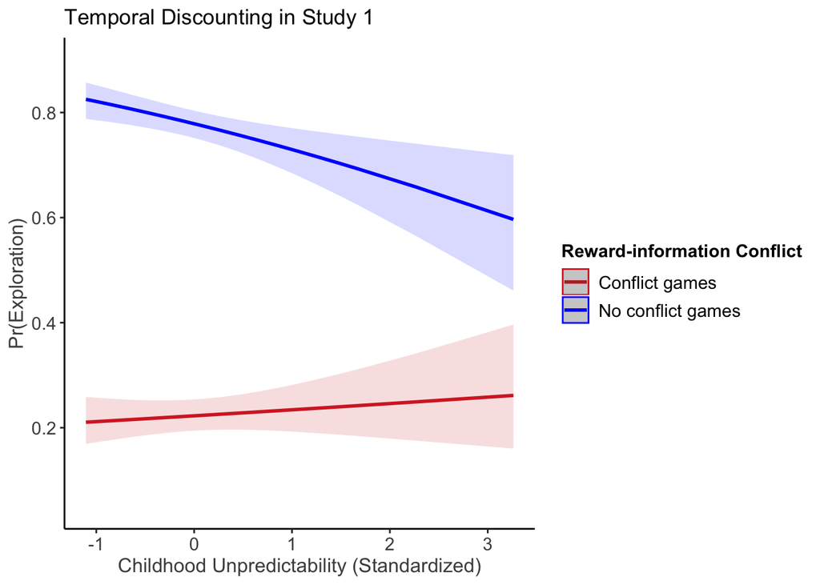

###### Study 2

```
## Generalized linear mixed model fit by maximum likelihood (Laplace
##   Approximation) [glmerMod]
##  Family: binomial  ( logit )
## Formula: chose_high_info_value ~ horizon * conflict * unpredictability +
##     digit_span + family_income + perceived_stress + (1 + horizon +
##     conflict | id)
##    Data: hr_long_study2
## Control: control
##
##      AIC      BIC   logLik deviance df.resid
##   6968.0   7082.6  -3467.0   6934.0     6223
##
## Scaled residuals:
##     Min      1Q  Median      3Q     Max
## -2.9279 -0.6027 -0.3052  0.6336  3.5595
##
## Random effects:
##  Groups Name        Variance Std.Dev. Corr
##  id     (Intercept) 0.5842   0.7643
##         horizon1    0.1522   0.3901   -0.19
##         conflict1   1.0541   1.0267   -0.90  0.05
## Number of obs: 6240, groups:  id, 78
##
## Fixed effects:
##                                      Estimate Std. Error z value Pr(>|z|)
## (Intercept)                         -1.759747   0.182360  -9.650  < 2e-16 ***
## horizon1                             0.428801   0.101841   4.211 2.55e-05 ***
## conflict1                            2.452605   0.148241  16.545  < 2e-16 ***
## unpredictability                    -0.051296   0.109501  -0.468 0.639461
## digit_span                           0.028334   0.049999   0.567 0.570929
## family_income                       -0.140188   0.050694  -2.765 0.005685 **
## perceived_stress                     0.019208   0.009128   2.104 0.035343 *
## horizon1:conflict1                  -0.480251   0.124268  -3.865 0.000111 ***
## horizon1:unpredictability           -0.188787   0.097505  -1.936 0.052844 .
## conflict1:unpredictability          -0.286307   0.140975  -2.031 0.042264 *
## horizon1:conflict1:unpredictability  0.193242   0.116466   1.659 0.097072 .
## ---
## Signif. codes:  0 '***' 0.001 '**' 0.01 '*' 0.05 '.' 0.1 ' ' 1
##
## Correlation of Fixed Effects:
##             (Intr) horzn1 cnflc1 unprdc dgt_sp fmly_n prcvd_ hrz1:1 hrzn1:
## horizon1    -0.278
## conflict1   -0.515  0.328
## unprdctblty  0.182  0.015  0.020
## digit_span  -0.026  0.005  0.008  0.010
## family_incm  0.245  0.005 -0.015  0.069 -0.154
## prcvd_strss -0.793 -0.018  0.001 -0.248  0.006 -0.286
## hrzn1:cnfl1  0.186 -0.665 -0.446 -0.016 -0.007 -0.009  0.026
## hrzn1:nprdc  0.001 -0.008 -0.008 -0.449  0.004 -0.008  0.007  0.007
## cnflct1:npr  0.006 -0.007 -0.039 -0.826  0.004 -0.004  0.007  0.028  0.315
## hrzn1:cnf1:  0.005  0.004  0.028  0.324 -0.007  0.012 -0.011 -0.054 -0.676
##             cnfl1:
## horizon1
## conflict1
## unprdctblty
## digit_span
## family_incm
## prcvd_strss
## hrzn1:cnfl1
## hrzn1:nprdc
## cnflct1:npr
## hrzn1:cnf1: -0.427
```

|  | chose high info value |  |  |
| --- | --- | --- | --- |
| Predictors | Odds Ratios | CI | p |
| (Intercept) | 0.17 | 0.12 – 0.25 | **<0.001** |
| horizon [1] | 1.54 | 1.26 – 1.87 | **<0.001** |
| conflict [1] | 11.62 | 8.69 – 15.54 | **<0.001** |
| unpredictability | 0.95 | 0.77 – 1.18 | 0.639 |
| digit span | 1.03 | 0.93 – 1.13 | 0.571 |
| family income | 0.87 | 0.79 – 0.96 | **0.006** |
| perceived stress | 1.02 | 1.00 – 1.04 | **0.035** |
| horizon [1] * conflict [1] | 0.62 | 0.48 – 0.79 | **<0.001** |
| horizon [1] * unpredictability | 0.83 | 0.68 – 1.00 | 0.053 |
| conflict [1] * unpredictability | 0.75 | 0.57 – 0.99 | **0.042** |
| (horizon [1] * conflict [1]) * unpredictability | 1.21 | 0.97 – 1.52 | 0.097 |
| Random Effects |  |  |  |
| σ<sup>2</sup> | 3.29 |  |  |
| τ<sub>00</sub> <sub>id</sub> | 0.58 |  |  |
| τ<sub>11</sub> <sub>id.horizon1</sub> | 0.15 |  |  |
| τ<sub>11</sub> <sub>id.conflict1</sub> | 1.05 |  |  |
| ρ<sub>01</sub> | -0.19 |  |  |
|  | -0.90 |  |  |
| ICC | 0.12 |  |  |
| N <sub>id</sub> | 78 |  |  |
| Observations | 6240 |  |  |
| Marginal R<sup>2</sup> / Conditional R<sup>2</sup> | 0.261 / 0.347 |  |  |

```
## $emtrends
##  conflict unpredictability.trend     SE  df asymp.LCL asymp.UCL
##  0                        -0.146 0.0978 Inf    -0.337    0.0461
##  1                        -0.335 0.0705 Inf    -0.474   -0.1972
##
## Results are averaged over the levels of: horizon
## Confidence level used: 0.95
##
## $contrasts
##  contrast              estimate    SE  df z.ratio p.value
##  conflict0 - conflict1     0.19 0.128 Inf   1.488  0.1369
##
## Results are averaged over the levels of: horizon
```

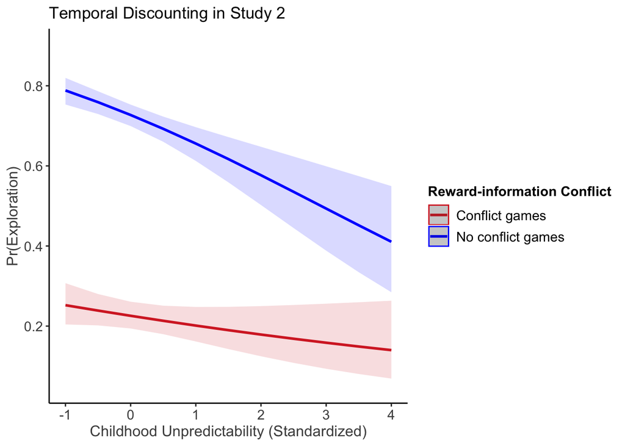

### Candidate mechanism 2: Habitual responding (**main text results**)

###### Study 1

In the model output below, check **fourth_choice_is_high_info_value_option:unpredictability** for whether there is an effect of childhood unpredictability on uncertainty-modulated habitual responding.

```
## Generalized linear mixed model fit by maximum likelihood (Laplace
##   Approximation) [glmerMod]
##  Family: binomial  ( logit )
## Formula: habitual_responding ~ fourth_choice_is_high_info_value_option *
##     unpredictability + digit_span + family_income + child_anxiety +
##     (1 + fourth_choice_is_high_info_value_option | id)
##    Data: hr_long_study1
## Control: control
##
##      AIC      BIC   logLik deviance df.resid
##   8511.7   8579.0  -4245.9   8491.7     6179
##
## Scaled residuals:
##     Min      1Q  Median      3Q     Max
## -1.1793 -0.9253 -0.7640  1.0262  1.5974
##
## Random effects:
##  Groups Name                                    Variance Std.Dev. Corr
##  id     (Intercept)                             0.09424  0.307
##         fourth_choice_is_high_info_value_option 0.16895  0.411    -0.93
## Number of obs: 6189, groups:  id, 78
##
## Fixed effects:
##                                                          Estimate Std. Error
## (Intercept)                                              -0.14593    0.04613
## fourth_choice_is_high_info_value_option                   0.02647    0.07428
## unpredictability                                          0.08900    0.05117
## digit_span                                                0.08972    0.03483
## family_income                                             0.03185    0.04030
## child_anxiety                                            -0.02428    0.03542
## fourth_choice_is_high_info_value_option:unpredictability -0.13417    0.07419
##                                                          z value Pr(>|z|)
## (Intercept)                                               -3.163  0.00156 **
## fourth_choice_is_high_info_value_option                    0.356  0.72156
## unpredictability                                           1.739  0.08200 .
## digit_span                                                 2.576  0.01000 **
## family_income                                              0.790  0.42943
## child_anxiety                                             -0.685  0.49311
## fourth_choice_is_high_info_value_option:unpredictability  -1.808  0.07055 .
## ---
## Signif. codes:  0 '***' 0.001 '**' 0.01 '*' 0.05 '.' 0.1 ' ' 1
##
## Correlation of Fixed Effects:
##             (Intr) fr______ unprdc dgt_sp fmly_n chld_n
## frth_c_____ -0.706
## unprdctblty -0.007 -0.002
## digit_span   0.000 -0.001    0.028
## family_incm  0.001 -0.007    0.392 -0.251
## child_anxty  0.030  0.006   -0.154  0.070 -0.065
## frth______:  0.002  0.006   -0.636 -0.010  0.003 -0.006
```

|  | habitual responding |  |  |
| --- | --- | --- | --- |
| Predictors | Odds Ratios | CI | p |
| (Intercept) | 0.86 | 0.79 – 0.95 | **0.002** |
| fourth choice is high info value option | 1.03 | 0.89 – 1.19 | 0.722 |
| unpredictability | 1.09 | 0.99 – 1.21 | 0.082 |
| digit span | 1.09 | 1.02 – 1.17 | **0.010** |
| family income | 1.03 | 0.95 – 1.12 | 0.429 |
| child anxiety | 0.98 | 0.91 – 1.05 | 0.493 |
| fourth choice is high info value option * unpredictability | 0.87 | 0.76 – 1.01 | 0.071 |
| Random Effects |  |  |  |
| σ<sup>2</sup> | 3.29 |  |  |
| τ<sub>00</sub> <sub>id</sub> | 0.09 |  |  |
| τ<sub>11</sub> <sub>id.fourth_choice_is_high_info_value_option</sub> | 0.17 |  |  |
| ρ<sub>01</sub> <sub>id</sub> | -0.93 |  |  |
| ICC | 0.02 |  |  |
| N <sub>id</sub> | 78 |  |  |
| Observations | 6189 |  |  |
| Marginal R<sup>2</sup> / Conditional R<sup>2</sup> | 0.004 / 0.027 |  |  |

```
## $emtrends
##  fourth_choice_is_high_info_value_option unpredictability.trend     SE  df
##                                        0                 0.0890 0.0512 Inf
##                                        1                -0.0452 0.0574 Inf
##  asymp.LCL asymp.UCL
##    -0.0113    0.1893
##    -0.1577    0.0673
##
## Confidence level used: 0.95
##
## $contrasts
##  contrast
##  fourth_choice_is_high_info_value_option0 - fourth_choice_is_high_info_value_option1
##  estimate     SE  df z.ratio p.value
##     0.134 0.0742 Inf   1.808  0.0705
```

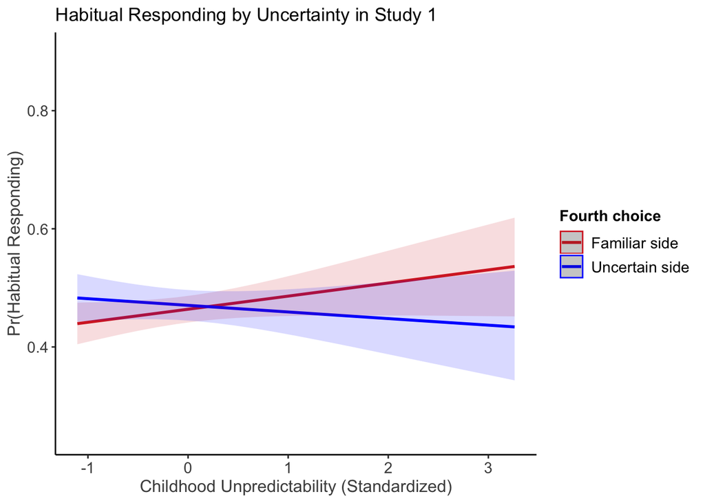

###### Study 2

```
## Generalized linear mixed model fit by maximum likelihood (Laplace
##   Approximation) [glmerMod]
##  Family: binomial  ( logit )
## Formula: habitual_responding ~ fourth_choice_is_high_info_value_option *
##     unpredictability + digit_span + family_income + perceived_stress +
##     (1 + fourth_choice_is_high_info_value_option | id)
##    Data: hr_long_study2
## Control: control
##
##      AIC      BIC   logLik deviance df.resid
##   8445.3   8512.7  -4212.7   8425.3     6230
##
## Scaled residuals:
##     Min      1Q  Median      3Q     Max
## -1.9888 -0.9226 -0.6281  0.9855  1.8333
##
## Random effects:
##  Groups Name                                    Variance Std.Dev. Corr
##  id     (Intercept)                             0.1614   0.4018
##         fourth_choice_is_high_info_value_option 0.1884   0.4341   -0.58
## Number of obs: 6240, groups:  id, 78
##
## Fixed effects:
##                                                           Estimate Std. Error
## (Intercept)                                               0.209321   0.148213
## fourth_choice_is_high_info_value_option                  -0.296394   0.078547
## unpredictability                                          0.288824   0.059455
## digit_span                                                0.072203   0.049199
## family_income                                             0.101887   0.049651
## perceived_stress                                         -0.013713   0.008665
## fourth_choice_is_high_info_value_option:unpredictability -0.175684   0.076626
##                                                          z value Pr(>|z|)
## (Intercept)                                                1.412 0.157862
## fourth_choice_is_high_info_value_option                   -3.773 0.000161 ***
## unpredictability                                           4.858 1.19e-06 ***
## digit_span                                                 1.468 0.142226
## family_income                                              2.052 0.040164 *
## perceived_stress                                          -1.583 0.113523
## fourth_choice_is_high_info_value_option:unpredictability  -2.293 0.021863 *
## ---
## Signif. codes:  0 '***' 0.001 '**' 0.01 '*' 0.05 '.' 0.1 ' ' 1
##
## Correlation of Fixed Effects:
##             (Intr) fr______ unprdc dgt_sp fmly_n prcvd_
## frth_c_____ -0.197
## unprdctblty  0.388  0.000
## digit_span  -0.059  0.018    0.019
## family_incm  0.285 -0.007    0.110 -0.199
## prcvd_strss -0.929  0.007   -0.422  0.039 -0.289
## frth______: -0.003 -0.026   -0.481 -0.010 -0.014  0.005
## optimizer (bobyqa) convergence code: 0 (OK)
## Model failed to converge with max|grad| = 0.00243764 (tol = 0.002, component 1)
```

|  | habitual responding |  |  |
| --- | --- | --- | --- |
| Predictors | Odds Ratios | CI | p |
| (Intercept) | 1.23 | 0.92 – 1.65 | 0.158 |
| fourth choice is high info value option | 0.74 | 0.64 – 0.87 | **<0.001** |
| unpredictability | 1.33 | 1.19 – 1.50 | **<0.001** |
| digit span | 1.07 | 0.98 – 1.18 | 0.142 |
| family income | 1.11 | 1.00 – 1.22 | **0.040** |
| perceived stress | 0.99 | 0.97 – 1.00 | 0.114 |
| fourth choice is high info value option * unpredictability | 0.84 | 0.72 – 0.97 | **0.022** |
| Random Effects |  |  |  |
| σ<sup>2</sup> | 3.29 |  |  |
| τ<sub>00</sub> <sub>id</sub> | 0.16 |  |  |
| τ<sub>11</sub> <sub>id.fourth_choice_is_high_info_value_option</sub> | 0.19 |  |  |
| ρ<sub>01</sub> <sub>id</sub> | -0.58 |  |  |
| ICC | 0.05 |  |  |
| N <sub>id</sub> | 78 |  |  |
| Observations | 6240 |  |  |
| Marginal R<sup>2</sup> / Conditional R<sup>2</sup> | 0.025 / 0.069 |  |  |

```
## $emtrends
##  fourth_choice_is_high_info_value_option unpredictability.trend     SE  df
##                                        0                  0.289 0.0595 Inf
##                                        1                  0.113 0.0709 Inf
##  asymp.LCL asymp.UCL
##     0.1723     0.405
##    -0.0258     0.252
##
## Confidence level used: 0.95
##
## $contrasts
##  contrast
##  fourth_choice_is_high_info_value_option0 - fourth_choice_is_high_info_value_option1
##  estimate     SE  df z.ratio p.value
##     0.176 0.0766 Inf   2.293  0.0219
```

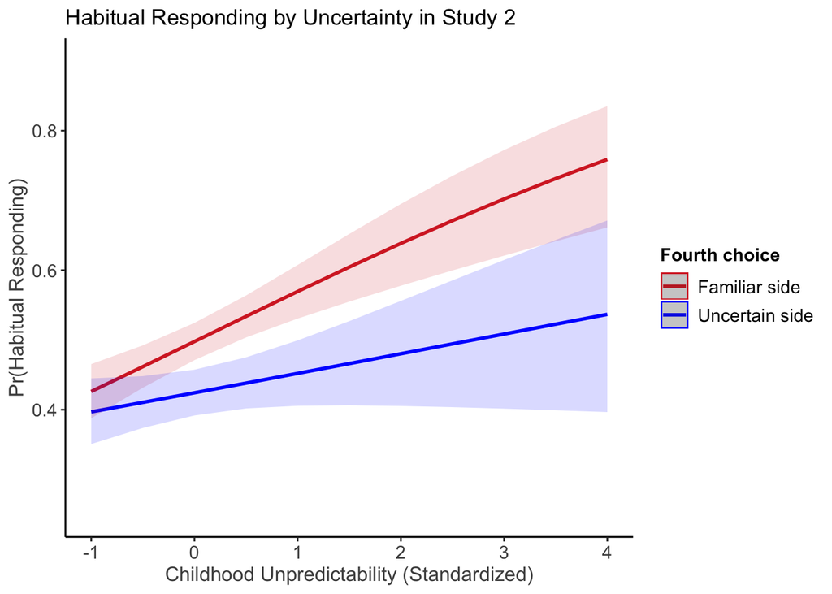

# Figure Plots

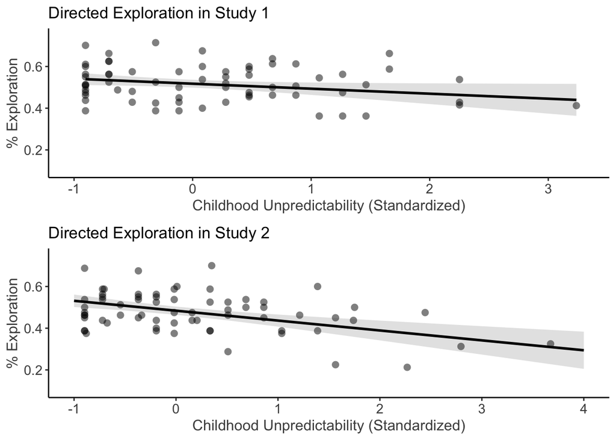

[figure not shown]

##### Mediation Analysis

###### Study 1

Uncertainty-modulated habitual responding mediates childhood unpredictability and reduced directed exploration in the Horizon task. In the model output below, check **ab** under **Defined Parameters** for whether there is there is a mediation effect.

```
## lavaan 0.6-12 ended normally after 1 iterations
##
##   Estimator                                         ML
##   Optimization method                           NLMINB
##   Number of model parameters                         9
##
##   Number of observations                            78
##
## Model Test User Model:
##
##   Test statistic                                 0.000
##   Degrees of freedom                                 0
##
## Parameter Estimates:
##
##   Standard errors                             Standard
##   Information                                 Expected
##   Information saturated (h1) model          Structured
##
## Regressions:
##                          Estimate  Std.Err  z-value  P(>|z|)
##   directed_exploration ~
##     unprdctblt (c)         -0.004    0.004   -0.923    0.356
##     digit_span              0.005    0.004    1.319    0.187
##     family_ncm             -0.000    0.004   -0.110    0.912
##   habit_low_info_value ~
##     unprdctblt (a)          0.026    0.013    1.966    0.049
##     digit_span              0.025    0.012    2.110    0.035
##     family_ncm              0.016    0.014    1.190    0.234
##   directed_exploration ~
##     hbt_lw_nf_ (b)         -0.756    0.036  -20.787    0.000
##
## Variances:
##                    Estimate  Std.Err  z-value  P(>|z|)
##    .directd_xplrtn    0.001    0.000    6.245    0.000
##    .habit_lw_nf_vl    0.010    0.002    6.245    0.000
##
## Defined Parameters:
##                    Estimate  Std.Err  z-value  P(>|z|)
##     ab               -0.020    0.010   -1.957    0.050
##     total            -0.024    0.011   -2.179    0.029
```

###### Study 2

```
## lavaan 0.6-12 ended normally after 1 iterations
##
##   Estimator                                         ML
##   Optimization method                           NLMINB
##   Number of model parameters                         9
##
##   Number of observations                            84
##
## Model Test User Model:
##
##   Test statistic                                 0.000
##   Degrees of freedom                                 0
##
## Parameter Estimates:
##
##   Standard errors                             Standard
##   Information                                 Expected
##   Information saturated (h1) model          Structured
##
## Regressions:
##                          Estimate  Std.Err  z-value  P(>|z|)
##   directed_exploration ~
##     unprdctblt (c)          0.001    0.004    0.193    0.847
##     digit_span              0.007    0.004    1.762    0.078
##     family_ncm              0.001    0.004    0.311    0.756
##   habit_low_info_value ~
##     unprdctblt (a)          0.058    0.013    4.641    0.000
##     digit_span              0.012    0.013    0.971    0.331
##     family_ncm              0.026    0.013    2.032    0.042
##   directed_exploration ~
##     hbt_lw_nf_ (b)         -0.695    0.033  -21.008    0.000
##
## Variances:
##                    Estimate  Std.Err  z-value  P(>|z|)
##    .directd_xplrtn    0.001    0.000    6.481    0.000
##    .habit_lw_nf_vl    0.013    0.002    6.481    0.000
##
## Defined Parameters:
##                    Estimate  Std.Err  z-value  P(>|z|)
##     ab               -0.040    0.009   -4.532    0.000
##     total            -0.040    0.009   -4.168    0.000
```